# Annual Fund $10K Model Data Exploration

# Goal

Clean up and explore the dataset generated with the `ksm-af-10k-data.sql` query with reusable R code.

# Setup

## Required packages

My code makes use of several packages:

```r
scan('PACKAGES.txt', what = 'character')
```

```
Read 9 items
```

```
[1] "devtools"  "wranglR"   "dplyr"     "tidyr"     "lubridate" "ggplot2"   "gridExtra" "knitr"
[9] "Boruta"
```

This code will install and load them as necessary. First, install `devtools` and my `wranglR` package:

```r
# Check to see if devtools is unavailable
if (!('devtools' %in% utils::installed.packages()[, 'Package'])) {
  # If unavailable, install it
  install.packages('devtools')
}
# Check to see if wranglR is unavailable
if (!('wranglR' %in% utils::installed.packages()[, 'Package'])) {
  # If unavailable, use devtools to install it via GitHub
  devtools::install_github('phively/wranglR')
}
```

## Load libraries

Now load `wranglR` and use it to install or load the other required packages:

```r
# Load wranglR
library(wranglR)
# Feed the libraries specified in PACKAGES.txt into wranglR's Libraries() function
Libraries(scan(file = 'PACKAGES.txt', what = 'character'))
```

```
Read 9 items
```

## Data preparation

```r
### Import the data
full.data <- read.csv('data/2017-12-08 AF 10K Model.csv', stringsAsFactors = FALSE, strip.white = TRUE,
                      colClasses = c('ID_NUMBER' = 'character'
                                     , 'HOUSEHOLD_ID' = 'character'
                                     , 'BIRTH_DT' = 'character'
                                     , 'GIVING_MAX_CASH_DT' = 'character'
                                     , 'GIVING_MAX_PLEDGE_DT' = 'character')) %>%
  # Drop any null rows
  filter(!is.na(RN)) %>%
  # Drop row numbers
  select(-RN)
### Clean the data
full.data <- full.data %>%
  # Convert NA to 0
  mutate_all(
    funs(
      ifelse(is.na(.), 0, .)
    )
  ) %>%
  # Convert to date
  mutate(
      DOB = ToDate(BIRTH_DT, method = 'ymd')
    , GIVING_MAX_CASH_DT = ToDate(GIVING_MAX_CASH_DT, method = 'mdy')
    , GIVING_MAX_PLEDGE_DT = ToDate(GIVING_MAX_CASH_DT, method = 'mdy')
  ) %>%
  # Extract dates
  mutate(
      GIVING_MAX_CASH_YR = year(GIVING_MAX_CASH_DT)
    , GIVING_MAX_CASH_MO = month(GIVING_MAX_CASH_DT) %>% factor()
  ) %>%
  # Convert certain character to factor
  mutate(
    # Factors
      RECORD_STATUS_CODE = factor(RECORD_STATUS_CODE) %>% relevel(ref = 'A') # Active
    , HOUSEHOLD_RECORD = factor(HOUSEHOLD_RECORD) %>% relevel(ref = 'AL') # Alumni
    , PROGRAM_GROUP = factor(PROGRAM_GROUP) %>% relevel(ref = 'FT') # Full-Time
    , PREF_ADDR_TYPE_CODE = factor(PREF_ADDR_TYPE_CODE) %>% relevel(ref = 'H') # Home
    , HOUSEHOLD_STATE = factor(HOUSEHOLD_STATE) %>% relevel(ref = 'IL') # Illinois
    , HOUSEHOLD_COUNTRY = factor(HOUSEHOLD_COUNTRY) %>% relevel(ref = 'United States')
    , HOUSEHOLD_CONTINENT = factor(HOUSEHOLD_CONTINENT) %>% relevel(ref = 'North America')
    , EVALUATION_RATING = factor(EVALUATION_RATING) %>% relevel(ref = '') # Unrated
    # Indicators
    , BUS_IS_EMPLOYED = factor(BUS_IS_EMPLOYED == 'Y')
    , BUS_HIGH_LVL_JOB_TITLE = factor(BUS_HIGH_LVL_JOB_TITLE != '')
    , BUS_CAREER_SPEC_FINANCE = factor(BUS_CAREER_SPEC_FINANCE != '')
    , BUS_GIFT_MATCH = factor(BUS_GIFT_MATCH == 'Y')
    , HAS_HOME_ADDR = factor(HAS_HOME_ADDR == 'Y')
    , HAS_ALT_HOME_ADDR = factor(HAS_ALT_HOME_ADDR == 'Y')
    , HAS_BUS_ADDR = factor(HAS_BUS_ADDR == 'Y')
    , HAS_SEASONAL_ADDR = factor(HAS_SEASONAL_ADDR == 'Y')
    , HAS_HOME_PHONE = factor(HAS_HOME_PHONE == 'Y')
    , HAS_BUS_PHONE = factor(HAS_BUS_PHONE == 'Y')
    , HAS_MOBILE_PHONE = factor(HAS_MOBILE_PHONE == 'Y')
    , HAS_HOME_EMAIL = factor(HAS_HOME_EMAIL == 'Y')
    , HAS_BUS_EMAIL = factor(HAS_BUS_EMAIL == 'Y')
    , KSM_PROSPECT_ACTIVE = factor(KSM_PROSPECT_ACTIVE == 'Y')
    , KSM_PROSPECT_ANY = factor(KSM_PROSPECT_ANY == 'Y')
  )
```

```
 27238 failed to parse.All formats failed to parse. No formats found.
```

“Failed to parse” means `DOB` is NA due to invalid `BIRTH_DT` format.

# Data Exploration

## Diagnostics

**Observations** from `summary(full.data)`

- Need to be cautious about the inserted 0s; e.g. discretize years?
- Should gift amounts be inflation-indexed? (CPI-U adjustment)
- DOB missing and impossible values: impute?

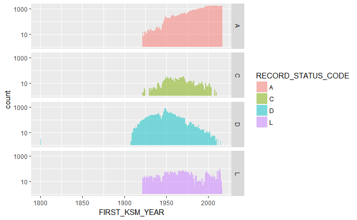

```r
full.data %>% filter(FIRST_KSM_YEAR != 0) %>%
  ggplot(aes(x = FIRST_KSM_YEAR, fill = RECORD_STATUS_CODE)) + geom_histogram(alpha = .5, binwidth = 1) +
  facet_grid(RECORD_STATUS_CODE ~ .) + scale_y_log10()
```

- Check 1800 grad year

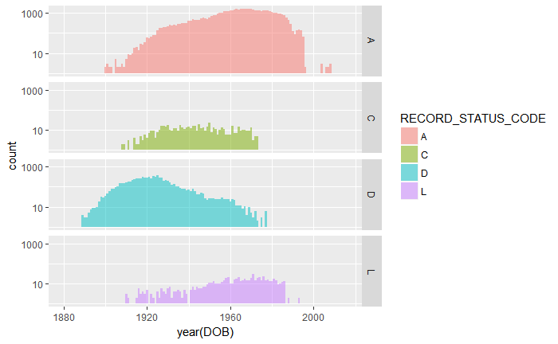

```r
full.data %>% filter(!is.na(DOB) & year(DOB) != 0) %>%
  ggplot(aes(x = year(DOB), fill = RECORD_STATUS_CODE)) + geom_histogram(alpha = .5, binwidth = 1) +
  facet_grid(RECORD_STATUS_CODE ~ .) + scale_y_log10()
```

- Check the person with DOB year 0
- Check people with DOB after 2000…or in general after they graduated?

## Inflation adjustment exploration

Plot largest nominal cash gift from each donor against the year in which it was made.

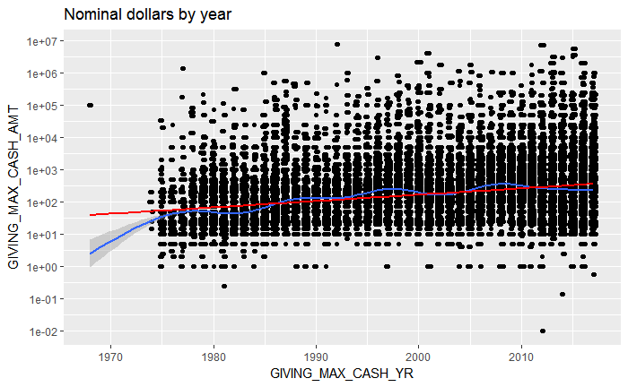

```r
full.data %>% filter(GIVING_MAX_CASH_AMT > 0) %>%
  ggplot(aes(x = GIVING_MAX_CASH_YR, y = GIVING_MAX_CASH_AMT)) +
  geom_point() + geom_jitter(width = .25, height = 0) +
  scale_y_log10(breaks = 10^(-2:7)) + geom_smooth() +
   # Red line is linear trend
  geom_smooth(method = 'lm', color = 'red') +
  labs(title = "Nominal dollars by year")
```

Slight upward slope over the last 30-40 years.

```r
# Load historical CPI-U data
cpi.u <- read.csv('data/CPI 2017-09-01.csv', strip.white = TRUE) %>%
  mutate(
    AS_OF = mdy(AS_OF)
    , YEAR = CALENDAR_YEAR
  )
cpi.max <- cpi.u %>% filter(CALENDAR_YEAR == max(CALENDAR_YEAR)) %>% select(CPI_U_AVG) %>% as.numeric()
```

Plot largest inflation-adjusted cash gift (Sept 2017 dollars) from each donor against the year in which it was made.

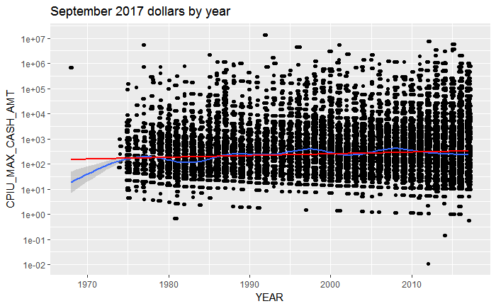

```r
full.data %>% filter(GIVING_MAX_CASH_AMT > 0) %>%
  # Join CPI-U columns
  mutate(YEAR = GIVING_MAX_CASH_YR) %>%
  inner_join(cpi.u, by = c('YEAR')) %>%
  # Compute inflation-adjusted amount
  mutate(CPIU_MAX_CASH_AMT = GIVING_MAX_CASH_AMT * cpi.max/CPI_U_AVG) %>%
  # Plot results
  ggplot(aes(x = YEAR, y = CPIU_MAX_CASH_AMT)) +
  geom_point() + geom_jitter(width = .25, height = 0) +
  scale_y_log10(breaks = 10^(-2:7)) + geom_smooth() +
  # Red line is linear trend
  geom_smooth(method = 'lm', color = 'red') +
  labs(title = "September 2017 dollars by year")
```

Inflation-adjusted there’s still a slight upward slope over time. Does look remarkably consistent over time.

## Response variable transformations

For Annual Giving, largest single cash gift is the logical response variable.

```r
summary2 <- function(x) {
  summary(x) %>% c(
    StDev = sd(x)
    , Skewnewss = e1071::skewness(x)
    , Kurtosis = e1071::kurtosis(x)
  ) %>% signif(digits = 3)
}
```

```r
full.data$GIVING_MAX_CASH_AMT %>% summary2()
```

```
     Min.   1st Qu.    Median      Mean   3rd Qu.      Max.     StDev Skewnewss  Kurtosis
 0.00e+00  0.00e+00  1.00e+01  2.73e+03  1.50e+02  7.84e+06  7.26e+04  6.56e+01  5.49e+03
```

```r
# Log10 transformation, no 0
{full.data %>% filter(GIVING_MAX_CASH_AMT > 0)}$GIVING_MAX_CASH_AMT %>% log10() %>% summary2()
```

```
     Min.   1st Qu.    Median      Mean   3rd Qu.      Max.     StDev Skewnewss  Kurtosis
   -2.000     1.700     2.180     2.250     2.700     6.900     0.773     0.886     2.150
```

```r
# Log10 transformation, with 0
{full.data$GIVING_MAX_CASH_AMT + 1} %>% log10() %>% summary2()
```

```
     Min.   1st Qu.    Median      Mean   3rd Qu.      Max.     StDev Skewnewss  Kurtosis
    0.000     0.000     1.040     1.160     2.180     6.900     1.250     0.576    -0.710
```

Giving is left-truncated at 0. I’d previously looked into alternate distributions with different datasets but the additional complexity was not worth it.

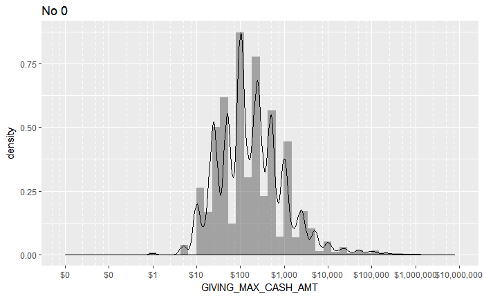

```r
# Density histogram
full.data %>% filter(GIVING_MAX_CASH_AMT > 0) %>%
  ggplot(aes(x = GIVING_MAX_CASH_AMT)) +
  geom_histogram(aes(y = ..density..), bins = 50, alpha = .5) +
  geom_density() +
  scale_x_log10(breaks = 10^(-2:7),
                minor_breaks = c(.25 * 10^(-2:7), .5 * 10^(-2:7), .75 * 10^(-2:7)),
                labels = scales::dollar) +
  theme(panel.grid.minor.x = element_line(linetype = 'dashed')) +
  labs(title = 'No 0')
```

Log scale appears to be a decent choice, though it’s still right-skewed.

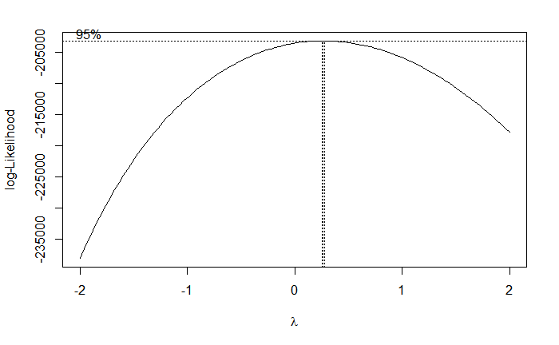

```r
# Box-Cox analysis
bc <- lm(log10(GIVING_MAX_CASH_AMT) ~ GIVING_MAX_CASH_YR, data = full.data %>% filter(GIVING_MAX_CASH_AMT > 1)) %>%
  MASS::boxcox()
```

```r
bc$x[which(bc$y == max(bc$y))]
```

```
[1] 0.2626263
```

According to this the best transformation on the 1-variable model is approximately $\sqrt[4]{\log(x)}$, which is quite hard to interpret. Log transformation is likely sufficient and has a reasonable explanation (error term $\epsilon$ enters multiplicatively).

## Response variable correlations

### Functions

```r
# ggplot2 boxplotting function from colname
boxplotter <- function(cname, data = full.data) {
  data %>% select(GIVING_MAX_CASH_AMT) %>% cbind(x = data[, cname]) %>%
    filter(GIVING_MAX_CASH_AMT > 0) %>%
    ggplot(aes(x = x, y = GIVING_MAX_CASH_AMT)) +
    geom_boxplot(alpha = .6) +
    scale_y_log10(breaks = 10^(-2:7), labels = scales::dollar) +
    labs(x = cname)
}
# ggplot2 scatterplotting function from colname
scatterplotter <- function(cname, data = full.data) {
  data %>% select(GIVING_MAX_CASH_AMT) %>% cbind(x = data[, cname]) %>%
    filter(GIVING_MAX_CASH_AMT > 0) %>%
    ggplot(aes(x = x, y = GIVING_MAX_CASH_AMT)) +
    geom_point(alpha = .6) +
    geom_smooth() +
    geom_smooth(method = 'lm', color = 'red') +
    scale_y_log10(breaks = 10^(-2:7), labels = scales::dollar) +
    labs(x = cname)
}
# ggplot2 histogram function from colname
histogrammer <- function(cname, m = 30, data = full.data) {
  data %>% cbind(x = data[, cname]) %>%
    ggplot(aes(x = x)) +
    geom_histogram(alpha = .6, bins = m) +
    geom_density(aes(y = ..count..)) +
    labs(x = cname)
}
```

### Categorical variables

```r
summary(full.data$RECORD_STATUS_CODE)
```

```
    A     C     D     L
71521  1259 16174  4251
```

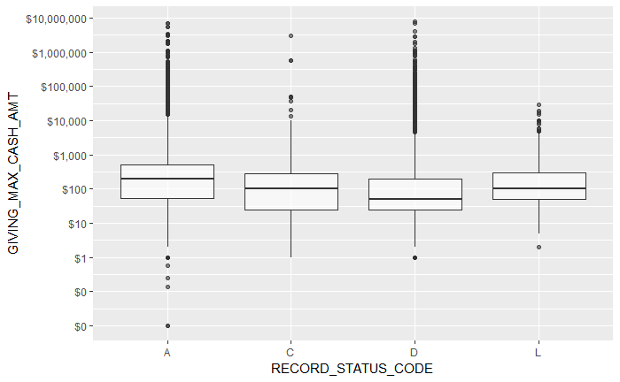

```r
boxplotter('RECORD_STATUS_CODE')
```

Good number within each factor and a meaningful indicator.

```r
summary(full.data$HOUSEHOLD_RECORD)
```

```
   AL     0    ST
88457  4724    24
```

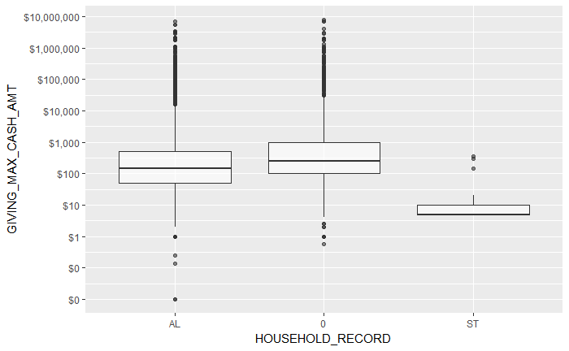

```r
boxplotter('HOUSEHOLD_RECORD')
```

Only a few students; good number of nonalumni. **Consider combining AL and ST**

```r
summary(full.data$HH_PRIMARY %>% as.factor())
```

```
    N     Y
 6984 86221
```

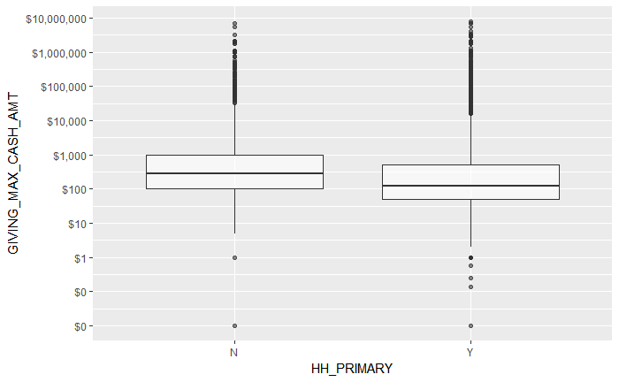

```r
boxplotter('HH_PRIMARY')
```

Should not include `N` in analysis as it duplicates a `Y` elsewhere in the file. **EXCLUDE**

```r
summary(full.data$PROGRAM_GROUP)
```

```
    FT           EMP EXECED NONGRD    PHD    TMP    UNK
 47134  11217  10689   7726   1754    786  13879     20
```

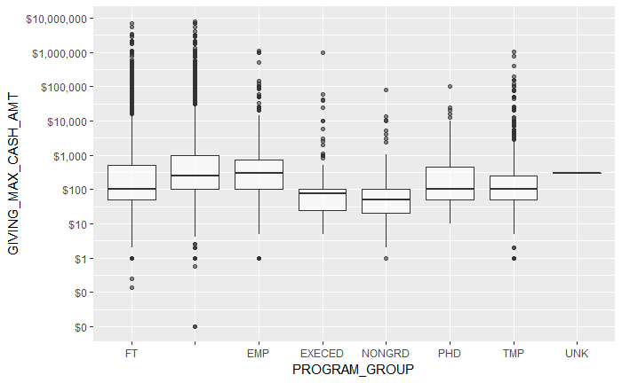

```r
boxplotter('PROGRAM_GROUP')
```

Only 20 UNK; others have a good number of rows. **Consider dropping UNK or treating as nonalum**

```r
summary(full.data$PREF_ADDR_TYPE_CODE)
```

```
    H     A    AB    AH     B     C     P     R     S    UB    UH    UX     X     Z
82211   613    40   598  9411     2     1    17    15    49   243     3     1     1
```

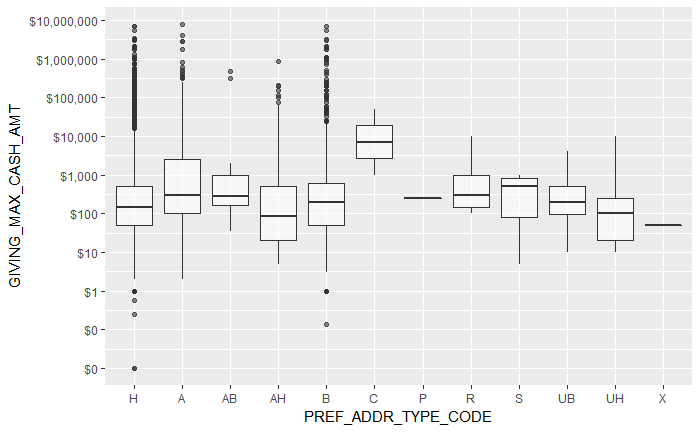

```r
boxplotter('PREF_ADDR_TYPE_CODE')
```

Several with very few examples; a few options here. Could combine all the Home-like and Business-like, and leave an Other for seasonal etc. Could also roll all the < 500, say, into an Other. **Consider combining categories**

```r
summary(full.data$HOUSEHOLD_STATE)
```

```
   IL          AB   ACT    AE    AK    AL    AP    AR    AZ    BC    CA    CO    CT    DC    DE
22615 30783    58     1     6    17    94     7   101   864    74  7106  1196   990   323    82
   FL    GA    HI    IA    ID    IN    KS    KY    LA    MA    MB    MD    ME    MI    MN    MO
 2876  1164   114   303    83   854   230   194    94  1636     4   682    79  1240  1204   606
   MP    MS    MT    NB    NC    ND    NE    NH    NJ    NL    NM    NS   NSW    NV    NY    OH
    1    36    54     3   986    14   125   129  1342     4   113     6   104   198  2846  1296
   OK    ON    OR    PA    PR    QC   QLD    RI    SA    SC    SD    SK   TAS    TN    TX    UT
  124   755   389  1132    30    69     7    75     3   295    30     3     1   486  2608   286
   VA    VI   VIC    VT    WA   WAU    WI    WV    WY
 1020     3    48    66  1262     8  1507    22    39
```

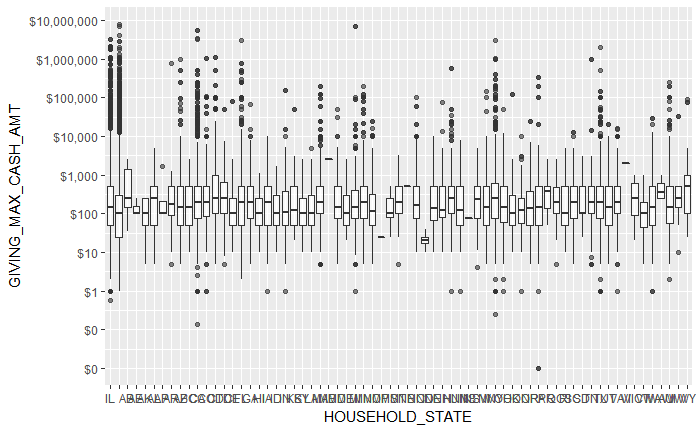

```r
boxplotter('HOUSEHOLD_STATE')
```

This appears to include Canadian and Australian states. Could also combine some of the lower-population areas. **Consider combining, perhaps based on region**

```r
summary(full.data$HOUSEHOLD_CONTINENT)
```

```
North America                      Africa          Asia        Europe       Oceania South America
        62817         21303           195          4470          3051           224          1145
```

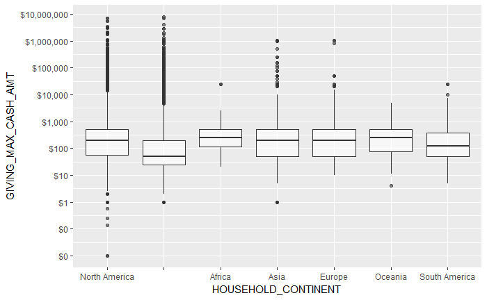

```r
boxplotter('HOUSEHOLD_CONTINENT')
```

Clear difference between those with and without an address; probably fine to include in model to suss out other differences.

```r
summary(full.data$BUS_IS_EMPLOYED)
```

```
FALSE  TRUE
41182 52023
```

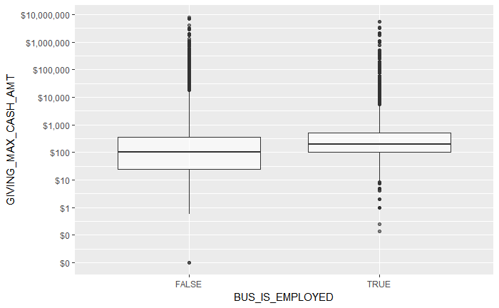

```r
boxplotter('BUS_IS_EMPLOYED')
```

Looks fine.

```r
summary(full.data$BUS_HIGH_LVL_JOB_TITLE)
```

```
FALSE  TRUE
76345 16860
```

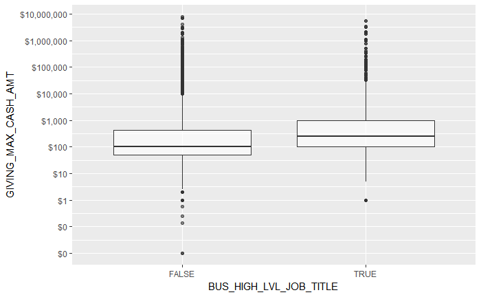

```r
boxplotter('BUS_HIGH_LVL_JOB_TITLE')
```

Looks fine.

```r
summary(full.data$BUS_CAREER_SPEC_FINANCE)
```

```
FALSE  TRUE
88983  4222
```

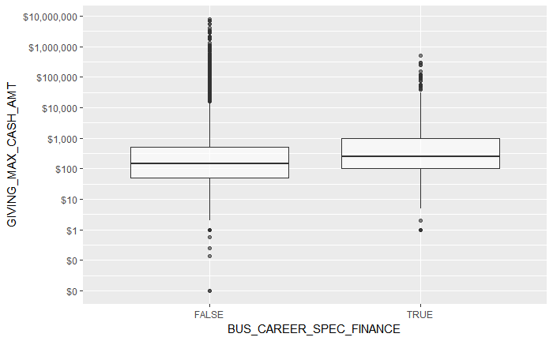

```r
boxplotter('BUS_CAREER_SPEC_FINANCE')
```

Looks fine.

```r
summary(full.data$BUS_GIFT_MATCH)
```

```
FALSE  TRUE
93097   108
```

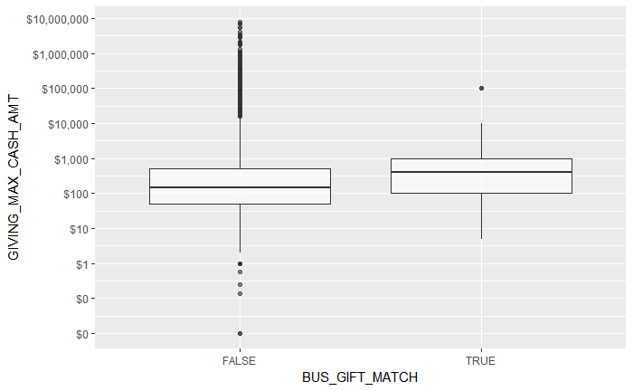

```r
boxplotter('BUS_GIFT_MATCH')
```

Very few that have matching companies; apparently this is not tracked consistently? **EXCLUDE**

```r
summary(full.data$HAS_HOME_ADDR)
```

```
FALSE  TRUE
23775 69430
```

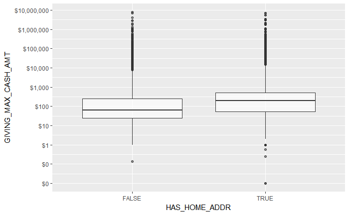

```r
boxplotter('HAS_HOME_ADDR')
```

Looks fine.

```r
summary(full.data$HAS_ALT_HOME_ADDR)
```

```
FALSE  TRUE
86337  6868
```

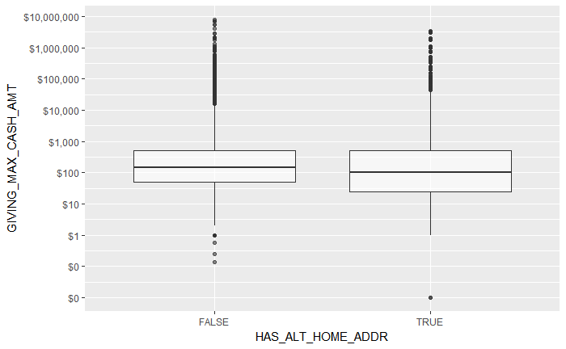

```r
boxplotter('HAS_ALT_HOME_ADDR')
```

Looks fine.

```r
summary(full.data$HAS_BUS_ADDR)
```

```
FALSE  TRUE
52059 41146
```

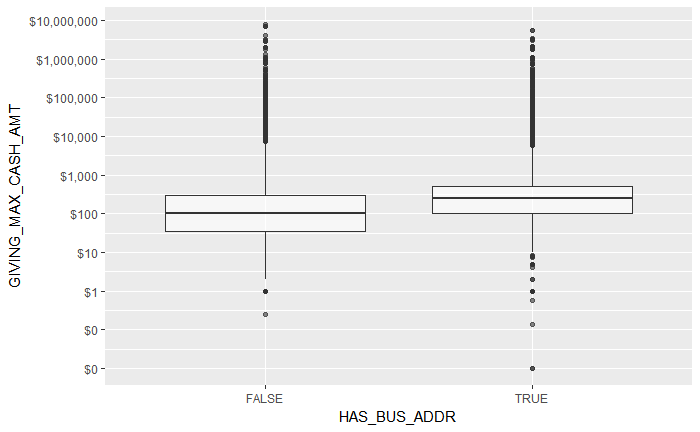

```r
boxplotter('HAS_BUS_ADDR')
```

Looks fine.

```r
summary(full.data$HAS_SEASONAL_ADDR)
```

```
FALSE  TRUE
92848   357
```

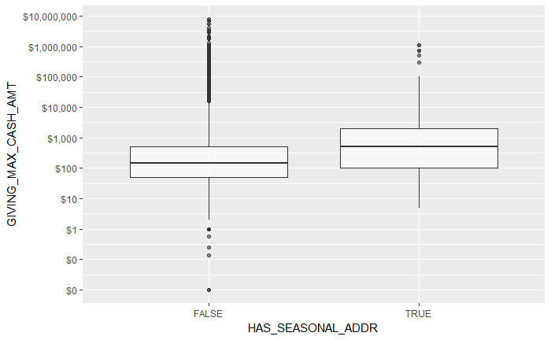

```r
boxplotter('HAS_SEASONAL_ADDR')
```

Low count. **Consider combining with alternate home address**

```r
summary(full.data$HAS_HOME_PHONE)
```

```
FALSE  TRUE
33917 59288
```

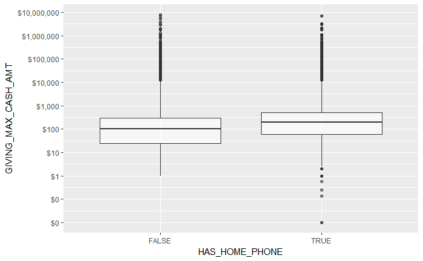

```r
boxplotter('HAS_HOME_PHONE')
```

Looks fine.

```r
summary(full.data$HAS_BUS_PHONE)
```

```
FALSE  TRUE
61667 31538
```

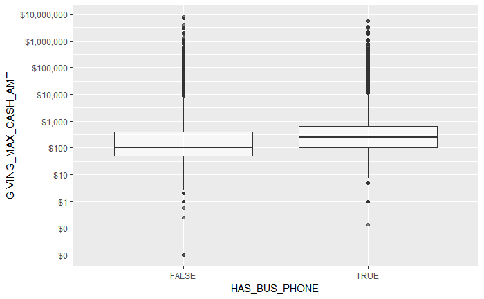

```r
boxplotter('HAS_BUS_PHONE')
```

Looks fine.

```r
summary(full.data$HAS_MOBILE_PHONE)
```

```
FALSE  TRUE
67919 25286
```

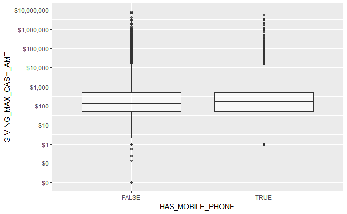

```r
boxplotter('HAS_MOBILE_PHONE')
```

Looks fine.

```r
summary(full.data$HAS_HOME_EMAIL)
```

```
FALSE  TRUE
40918 52287
```

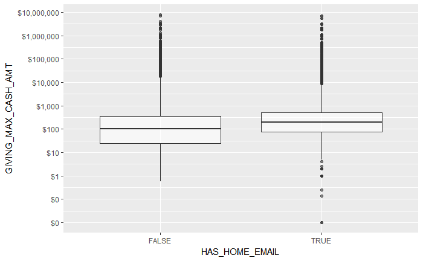

```r
boxplotter('HAS_HOME_EMAIL')
```

Looks fine.

```r
summary(full.data$HAS_BUS_EMAIL)
```

```
FALSE  TRUE
65483 27722
```

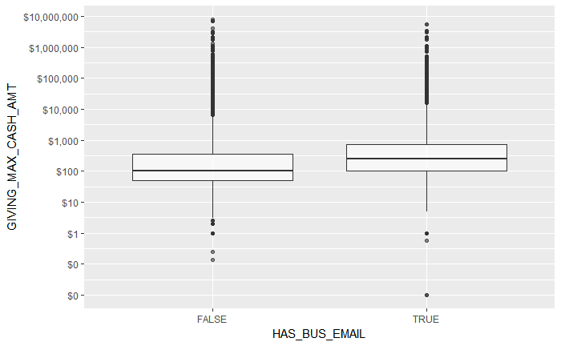

```r
boxplotter('HAS_BUS_EMAIL')
```

Looks fine.

```r
summary(full.data$EVALUATION_RATING)
```

```
                        A1 $100M+  A2 $50M - 99.9M A3 $25M - $49.9M A4 $10M - $24.9M
           83716               54               26               51               99
  A5 $5M - $9.9M   A6 $2M - $4.9M   A7 $1M - $1.9M B  $500K - $999K C  $250K - $499K
             173              337              549             1166             2427
D  $100K - $249K   E  $50K - $99K   F  $25K - $49K   G  $10K - $24K    H  Under $10K
            2598              679              785              470               75
```

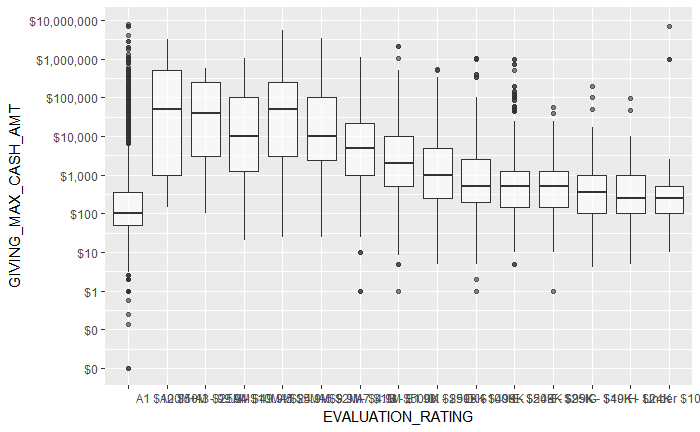

```r
boxplotter('EVALUATION_RATING')
```

Would likely combine all the $1M+ levels. Note that the evaluation rating process is causally associated with solicitations and thus gift size. **CAUTION - endogenous**

```r
summary(full.data$KSM_PROSPECT_ACTIVE)
```

```
FALSE  TRUE
85822  7383
```

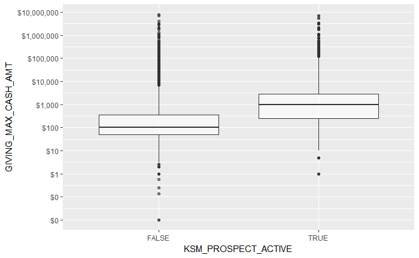

```r
boxplotter('KSM_PROSPECT_ACTIVE')
```

Looks fine.

```r
summary(full.data$KSM_PROSPECT_ANY)
```

```
FALSE  TRUE
83373  9832
```

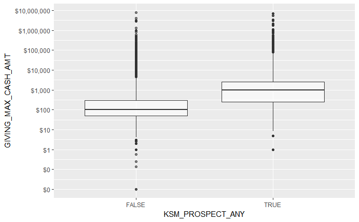

```r
boxplotter('KSM_PROSPECT_ANY')
```

Looks fine. **Consider making a new factor combining `KSM_PROSPECT_ACTIVE` and `KSM_PROSPECT_ANY`**

```r
# Derived variable
full.data <- full.data %>% mutate(
  KSM_PROSPECT = case_when(
    KSM_PROSPECT_ACTIVE == TRUE ~ 'Current'
    , KSM_PROSPECT_ANY == TRUE ~ 'Past'
    , TRUE ~ 'No') %>% factor()
)
summary(full.data$KSM_PROSPECT)
```

```
Current      No    Past
   7383   83373    2449
```

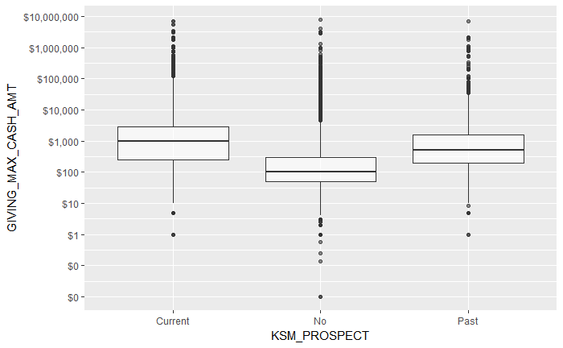

```r
boxplotter('KSM_PROSPECT')
```

Looks good.

```r
summary(full.data$GIVING_MAX_CASH_MO)
```

```
    1     2     3     4     5     6     7     8     9    10    11    12  NA's
 2575  2395  2924  3664  5067  5521  2530  4079  1546  2558  4074 10782 45490
```

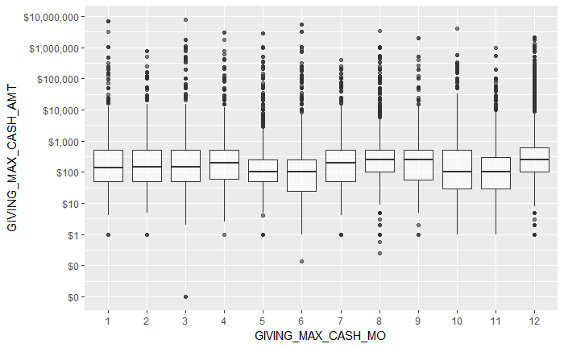

```r
boxplotter('GIVING_MAX_CASH_MO')
```

Looks good.

### Numeric variables

Uses $\log_{10}$ transformation for dollars and $\sqrt{\ \ }$ transformation for counts.

```r
summary2(full.data$FIRST_KSM_YEAR)
```

```
     Min.   1st Qu.    Median      Mean   3rd Qu.      Max.     StDev Skewnewss  Kurtosis
     0.00   1950.00   1990.00   1710.00   2000.00   2020.00    688.00     -2.08      2.32
```

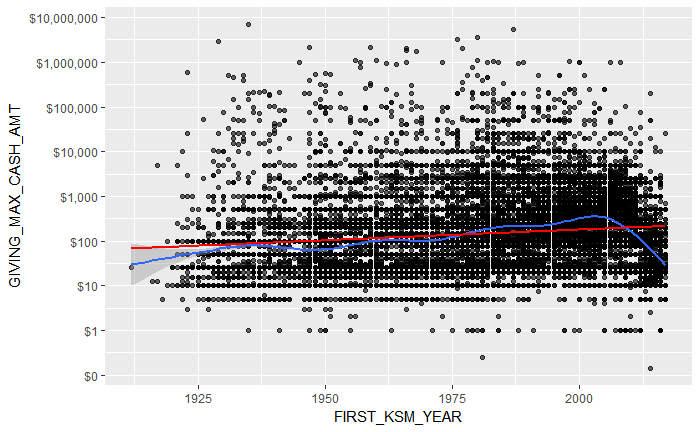

```r
scatterplotter('FIRST_KSM_YEAR', full.data %>% filter(FIRST_KSM_YEAR > 0))
```

Appears approximately linear until people graduating ~10 years ago.

```r
summary2(full.data$GIVING_FIRST_YEAR)
```

```
     Min.   1st Qu.    Median      Mean   3rd Qu.      Max.     StDev Skewnewss  Kurtosis
   0.0000    0.0000 1980.0000 1020.0000 2000.0000 2020.0000  998.0000   -0.0512   -2.0000
```

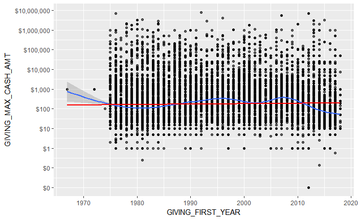

```r
scatterplotter('GIVING_FIRST_YEAR')
```

Same as previous.

```r
summary2(full.data %>% select(GIVING_FIRST_YEAR_CASH_AMT) %>%
  filter(GIVING_FIRST_YEAR_CASH_AMT > 0) %>% unlist() %>% log10())
```

```
     Min.   1st Qu.    Median      Mean   3rd Qu.      Max.     StDev Skewnewss  Kurtosis
   -2.000     1.400     1.700     1.850     2.180     7.200     0.676     1.040     2.870
```

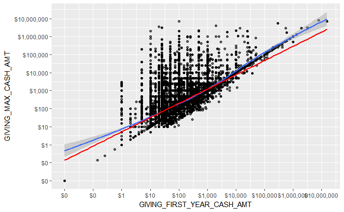

```r
scatterplotter('GIVING_FIRST_YEAR_CASH_AMT'
               , full.data %>% filter(GIVING_FIRST_YEAR_CASH_AMT > 0)) +
  scale_x_log10(breaks = 10^(-2:7), labels = scales::dollar)
```

Nearly an $x = y$ dividing line; not expected to be exact given that `GIVING_MAX_CASH_AMT` is single gifts. **CAUTION - endogenous**

```r
summary2(full.data %>% select(GIVING_FIRST_YEAR_PLEDGE_AMT) %>%
  filter(GIVING_FIRST_YEAR_PLEDGE_AMT > 0) %>% unlist() %>% log10())
```

```
     Min.   1st Qu.    Median      Mean   3rd Qu.      Max.     StDev Skewnewss  Kurtosis
    0.000     2.100     2.480     2.490     2.880     6.780     0.602     0.515     3.840
```

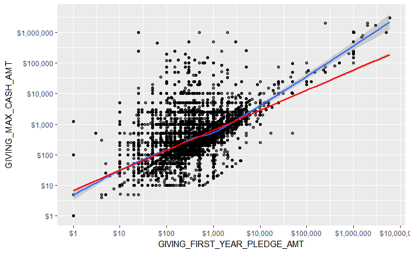

```r
scatterplotter('GIVING_FIRST_YEAR_PLEDGE_AMT'
               , full.data %>% filter(GIVING_FIRST_YEAR_PLEDGE_AMT > 0)) +
  scale_x_log10(breaks = 10^(-2:7), labels = scales::dollar)
```

Looks ok, but probably need a cutoff. **CAUTION - endogenous**

```r
summary2(full.data %>% select(GIVING_CASH_TOTAL) %>%
  filter(GIVING_CASH_TOTAL > 0) %>% unlist() %>% log10())
```

```
     Min.   1st Qu.    Median      Mean   3rd Qu.      Max.     StDev Skewnewss  Kurtosis
   -2.000     2.000     2.650     2.650     3.210     7.230     0.918     0.439     0.586
```

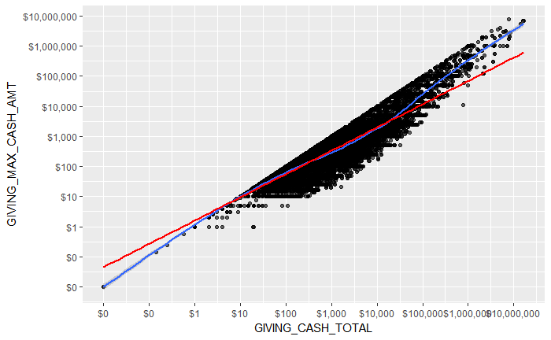

```r
scatterplotter('GIVING_CASH_TOTAL'
               , full.data %>% filter(GIVING_CASH_TOTAL > 0)) +
  scale_x_log10(breaks = 10^(-2:7), labels = scales::dollar)
```

Linear trend bounded by $y = x$ as expected. **EXCLUDE**

```r
summary2(full.data %>% select(GIVING_PLEDGE_TOTAL) %>%
  filter(GIVING_PLEDGE_TOTAL > 0) %>% unlist() %>% log10())
```

```
     Min.   1st Qu.    Median      Mean   3rd Qu.      Max.     StDev Skewnewss  Kurtosis
     0.00      2.00      2.48      2.57      3.00      7.18      0.81      1.39      4.30
```

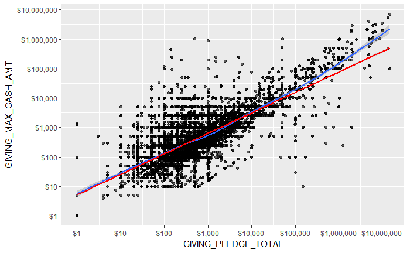

```r
scatterplotter('GIVING_PLEDGE_TOTAL'
               , full.data %>% filter(GIVING_PLEDGE_TOTAL > 0)) +
  scale_x_log10(breaks = 10^(-2:7), labels = scales::dollar)
```

Appears linear or piecewise linear, which follows given pledge payments. **EXCLUDE**

```r
summary2(full.data %>% select(GIVING_NGC_TOTAL) %>%
  filter(GIVING_NGC_TOTAL > 0) %>% unlist() %>% log10())
```

```
     Min.   1st Qu.    Median      Mean   3rd Qu.      Max.     StDev Skewnewss  Kurtosis
   -2.000     2.000     2.650     2.660     3.220     7.230     0.929     0.493     0.768
```

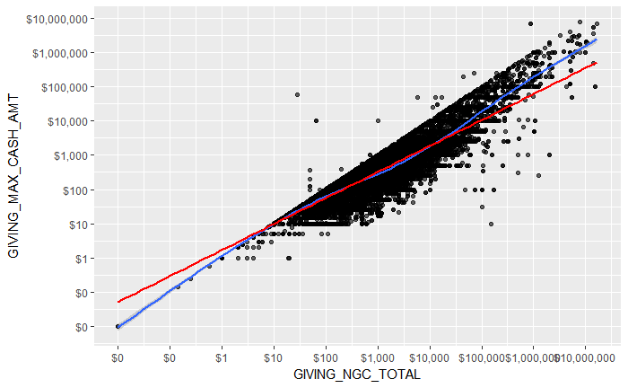

```r
scatterplotter('GIVING_NGC_TOTAL'
               , full.data %>% filter(GIVING_NGC_TOTAL > 0)) +
  scale_x_log10(breaks = 10^(-2:7), labels = scales::dollar)
```

Same as previous. **EXCLUDE**

```r
summary2(full.data$GIFTS_ALLOCS_SUPPORTED %>% sqrt())
```

```
     Min.   1st Qu.    Median      Mean   3rd Qu.      Max.     StDev Skewnewss  Kurtosis
    0.000     0.000     1.000     0.641     1.000     4.240     0.676     0.475    -0.854
```

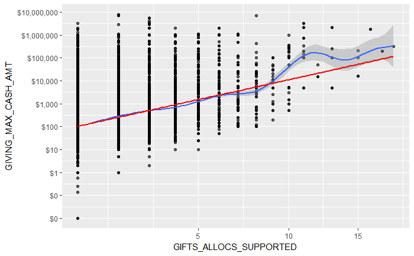

```r
scatterplotter('GIFTS_ALLOCS_SUPPORTED') +
  scale_x_sqrt()
```

Looks ok.

```r
summary2(full.data$GIFTS_FYS_SUPPORTED %>% sqrt())
```

```
     Min.   1st Qu.    Median      Mean   3rd Qu.      Max.     StDev Skewnewss  Kurtosis
     0.00      0.00      1.00      1.08      1.73      6.56      1.34      1.27      1.13
```

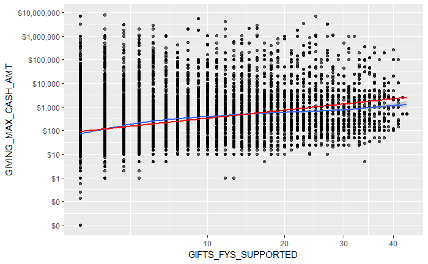

```r
scatterplotter('GIFTS_FYS_SUPPORTED') +
  scale_x_sqrt()
```

Looks ok.

```r
summary2(full.data$GIFTS_CASH %>% sqrt())
```

```
     Min.   1st Qu.    Median      Mean   3rd Qu.      Max.     StDev Skewnewss  Kurtosis
    0.000     0.000     0.000     0.788     1.410    17.500     1.260     1.850     3.540
```

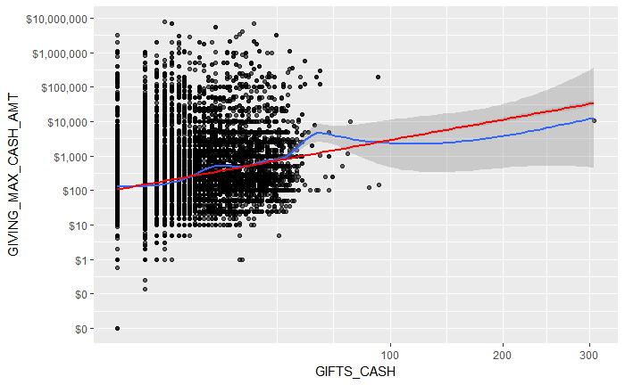

```r
scatterplotter('GIFTS_CASH') +
  scale_x_sqrt()
```

Would want to exclude the influential point around $x = 300$ if this is used. **Consider additional transformation**

```r
summary2(full.data$GIFTS_CREDIT_CARD %>% sqrt())
```

```
     Min.   1st Qu.    Median      Mean   3rd Qu.      Max.     StDev Skewnewss  Kurtosis
    0.000     0.000     0.000     0.436     1.000     8.060     0.846     2.250     5.730
```

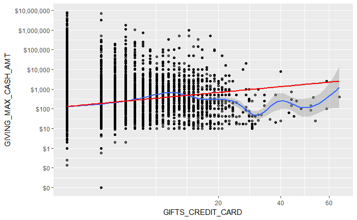

```r
scatterplotter('GIFTS_CREDIT_CARD') +
  scale_x_sqrt()
```

Looks ok; candidate for discretizing. **Consider additional transformation**

```r
summary2(full.data$GIFTS_STOCK %>% sqrt())
```

```
     Min.   1st Qu.    Median      Mean   3rd Qu.      Max.     StDev Skewnewss  Kurtosis
   0.0000    0.0000    0.0000    0.0205    0.0000    6.6300    0.2050   12.6000  194.0000
```

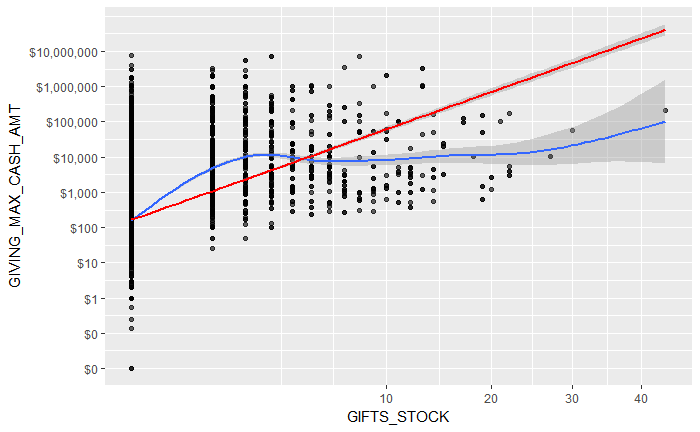

```r
scatterplotter('GIFTS_STOCK') +
  scale_x_sqrt()
```

Completely different 0 and 1+ slopes. Could be a candidate for binary indicator. **Consider additional transformation**

```r
rbind(
    summary2(full.data %>% select(CASH_PFY1) %>% filter(CASH_PFY1 > 0) %>% unlist() %>% log10())
  , summary2(full.data %>% select(CASH_PFY2) %>% filter(CASH_PFY2 > 0) %>% unlist() %>% log10())
  , summary2(full.data %>% select(CASH_PFY3) %>% filter(CASH_PFY3 > 0) %>% unlist() %>% log10())
  , summary2(full.data %>% select(CASH_PFY4) %>% filter(CASH_PFY4 > 0) %>% unlist() %>% log10())
  , summary2(full.data %>% select(CASH_PFY5) %>% filter(CASH_PFY5 > 0) %>% unlist() %>% log10())
)
```

```
       Min. 1st Qu. Median Mean 3rd Qu. Max. StDev Skewnewss Kurtosis
[1,] -0.252       2   2.40 2.49     3.0 6.32 0.822     0.854     1.39
[2,]  0.000       2   2.40 2.45     3.0 6.30 0.796     0.705     1.03
[3,]  0.000       2   2.40 2.45     3.0 6.92 0.804     0.610     1.58
[4,] -0.854       2   2.40 2.44     3.0 6.48 0.782     0.846     1.77
[5,]  0.000       2   2.33 2.39     2.7 6.61 0.717     0.888     2.19
```

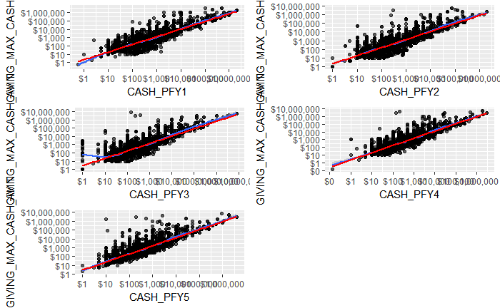

```r
# Grid plot
grid.arrange(
    scatterplotter('CASH_PFY1', full.data %>% filter(CASH_PFY1 > 0)) +
      scale_x_log10(breaks = 10^(-2:7), labels = scales::dollar)
  , scatterplotter('CASH_PFY2', full.data %>% filter(CASH_PFY2 > 0)) +
      scale_x_log10(breaks = 10^(-2:7), labels = scales::dollar)
  , scatterplotter('CASH_PFY3', full.data %>% filter(CASH_PFY3 > 0)) +
      scale_x_log10(breaks = 10^(-2:7), labels = scales::dollar)
  , scatterplotter('CASH_PFY4', full.data %>% filter(CASH_PFY4 > 0)) +
      scale_x_log10(breaks = 10^(-2:7), labels = scales::dollar)
  , scatterplotter('CASH_PFY5', full.data %>% filter(CASH_PFY5 > 0)) +
      scale_x_log10(breaks = 10^(-2:7), labels = scales::dollar)
)
```

High year-to-year correlations as expected. **CAUTION - endogenous**

```r
rbind(
    summary2(full.data %>% select(NGC_PFY1) %>% filter(NGC_PFY1 > 0) %>% unlist() %>% log10())
  , summary2(full.data %>% select(NGC_PFY2) %>% filter(NGC_PFY2 > 0) %>% unlist() %>% log10())
  , summary2(full.data %>% select(NGC_PFY3) %>% filter(NGC_PFY3 > 0) %>% unlist() %>% log10())
  , summary2(full.data %>% select(NGC_PFY4) %>% filter(NGC_PFY4 > 0) %>% unlist() %>% log10())
  , summary2(full.data %>% select(NGC_PFY5) %>% filter(NGC_PFY5 > 0) %>% unlist() %>% log10())
)
```

```
       Min. 1st Qu. Median Mean 3rd Qu. Max. StDev Skewnewss Kurtosis
[1,] -0.252       2    2.4 2.48     3.0 7.18 0.834     0.966     2.02
[2,] -1.400       2    2.4 2.46     3.0 7.06 0.787     0.641     1.34
[3,]  0.000       2    2.4 2.45     3.0 7.13 0.768     0.416     1.35
[4,] -0.854       2    2.4 2.44     3.0 7.00 0.787     0.920     2.19
[5,]  0.000       2    2.3 2.37     2.7 6.78 0.726     1.070     3.08
```

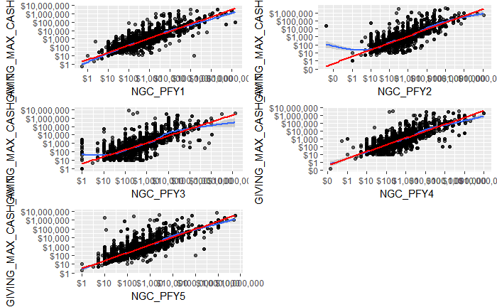

```r
# Grid plot
grid.arrange(
    scatterplotter('NGC_PFY1', full.data %>% filter(NGC_PFY1 > 0)) +
      scale_x_log10(breaks = 10^(-2:7), labels = scales::dollar)
  , scatterplotter('NGC_PFY2', full.data %>% filter(NGC_PFY2 > 0)) +
      scale_x_log10(breaks = 10^(-2:7), labels = scales::dollar)
  , scatterplotter('NGC_PFY3', full.data %>% filter(NGC_PFY3 > 0)) +
      scale_x_log10(breaks = 10^(-2:7), labels = scales::dollar)
  , scatterplotter('NGC_PFY4', full.data %>% filter(NGC_PFY4 > 0)) +
      scale_x_log10(breaks = 10^(-2:7), labels = scales::dollar)
  , scatterplotter('NGC_PFY5', full.data %>% filter(NGC_PFY5 > 0)) +
      scale_x_log10(breaks = 10^(-2:7), labels = scales::dollar)
)
```

Same as above. **CAUTION - endogenous**

```r
summary2(full.data$GIFT_CLUB_KLC_YRS %>% sqrt())
```

```
     Min.   1st Qu.    Median      Mean   3rd Qu.      Max.     StDev Skewnewss  Kurtosis
    0.000     0.000     0.000     0.109     0.000     3.320     0.444     4.490    20.700
```

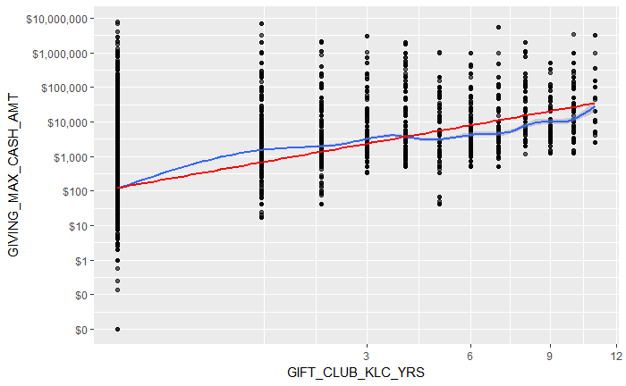

```r
scatterplotter('GIFT_CLUB_KLC_YRS') +
  scale_x_sqrt()
```

Surprisingly close to linear; looks ok.

```r
summary2(full.data$GIFT_CLUB_BEQUEST_YRS %>% sqrt())
```

```
     Min.   1st Qu.    Median      Mean   3rd Qu.      Max.     StDev Skewnewss  Kurtosis
 0.00e+00  0.00e+00  0.00e+00  9.14e-03  0.00e+00  1.41e+00  9.52e-02  1.03e+01  1.05e+02
```

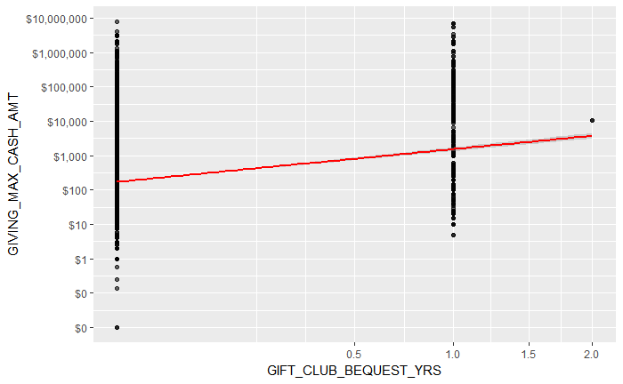

```r
scatterplotter('GIFT_CLUB_BEQUEST_YRS') +
  scale_x_sqrt()
```

Only 1 point with 2, so good candidate for binary indicator. **Consider additional transformation**

```r
summary2(full.data$GIFT_CLUB_LOYAL_YRS %>% sqrt())
```

```
     Min.   1st Qu.    Median      Mean   3rd Qu.      Max.     StDev Skewnewss  Kurtosis
    0.000     0.000     0.000     0.239     0.000     2.450     0.613     2.450     4.670
```

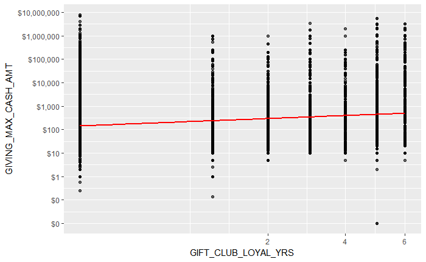

```r
scatterplotter('GIFT_CLUB_LOYAL_YRS') +
  scale_x_sqrt()
```

Looks ok but check how many are at each level. **Consider additional transformation**

```r
summary2(full.data$GIFT_CLUB_NU_LDR_YRS %>% sqrt())
```

```
     Min.   1st Qu.    Median      Mean   3rd Qu.      Max.     StDev Skewnewss  Kurtosis
    0.000     0.000     0.000     0.216     0.000     4.000     0.665     3.340    10.900
```

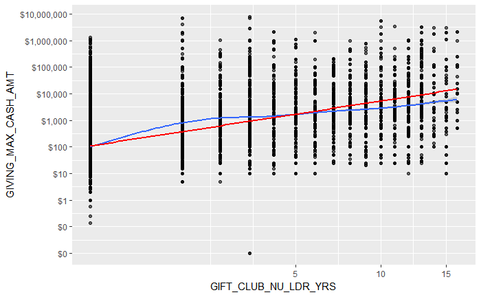

```r
scatterplotter('GIFT_CLUB_NU_LDR_YRS') +
  scale_x_sqrt()
```

Looks ok but check how many are at each level. **Consider additional transformation**

```r
rbind(
    summary2(full.data$VISITS_PFY1 %>% sqrt())
  , summary2(full.data$VISITS_PFY2 %>% sqrt())
  , summary2(full.data$VISITS_PFY3 %>% sqrt())
  , summary2(full.data$VISITS_PFY4 %>% sqrt())
  , summary2(full.data$VISITS_PFY5 %>% sqrt())
)
```

```
     Min. 1st Qu. Median   Mean 3rd Qu. Max. StDev Skewnewss Kurtosis
[1,]    0       0      0 0.0240       0 3.61 0.173      8.06     74.5
[2,]    0       0      0 0.0242       0 3.16 0.174      7.82     67.6
[3,]    0       0      0 0.0232       0 3.46 0.168      7.97     71.7
[4,]    0       0      0 0.0245       0 3.32 0.172      7.61     63.9
[5,]    0       0      0 0.0232       0 3.32 0.168      7.87     68.9
```

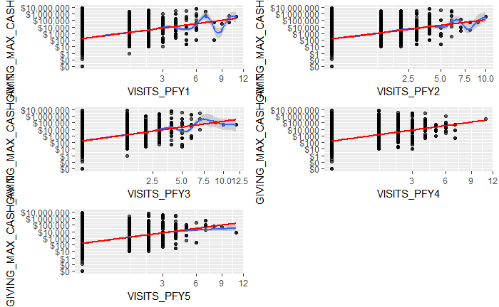

```r
# Grid plot
grid.arrange(
    scatterplotter('VISITS_PFY1') + scale_x_sqrt()
  , scatterplotter('VISITS_PFY2') + scale_x_sqrt()
  , scatterplotter('VISITS_PFY3') + scale_x_sqrt()
  , scatterplotter('VISITS_PFY4') + scale_x_sqrt()
  , scatterplotter('VISITS_PFY5') + scale_x_sqrt()
)
```

Hard to see what’s going on past 6 visits; seems to be about linear until then in each case. Try combining 5 years of visit counts.

```r
full.data <- full.data %>% mutate(
  VISITS = VISITS_PFY1 + VISITS_PFY2 + VISITS_PFY3 + VISITS_PFY4 + VISITS_PFY5
)
summary2(full.data$VISITS)
```

```
     Min.   1st Qu.    Median      Mean   3rd Qu.      Max.     StDev Skewnewss  Kurtosis
    0.000     0.000     0.000     0.149     0.000    40.000     0.978    15.100   351.000
```

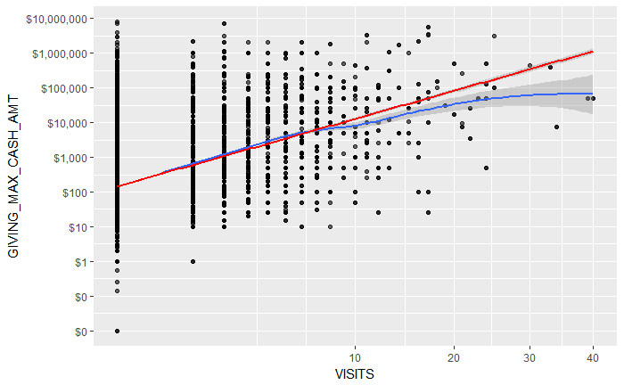

```r
scatterplotter('VISITS') + scale_x_sqrt()
```

More of a logarithmic relationship. **Consider log transformation**

```r
rbind(
    summary2(full.data$VISITORS_PFY1 %>% sqrt())
  , summary2(full.data$VISITORS_PFY2 %>% sqrt())
  , summary2(full.data$VISITORS_PFY3 %>% sqrt())
  , summary2(full.data$VISITORS_PFY4 %>% sqrt())
  , summary2(full.data$VISITORS_PFY5 %>% sqrt())
)
```

```
     Min. 1st Qu. Median   Mean 3rd Qu. Max. StDev Skewnewss Kurtosis
[1,]    0       0      0 0.0226       0 2.83 0.161      7.48     59.6
[2,]    0       0      0 0.0229       0 2.83 0.162      7.43     58.5
[3,]    0       0      0 0.0220       0 2.65 0.157      7.45     58.5
[4,]    0       0      0 0.0229       0 2.65 0.158      7.16     53.8
[5,]    0       0      0 0.0219       0 2.24 0.155      7.32     55.3
```

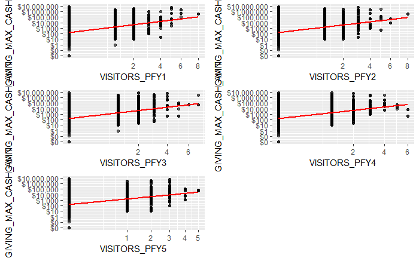

```r
# Grid plot
grid.arrange(
    scatterplotter('VISITORS_PFY1') + scale_x_sqrt()
  , scatterplotter('VISITORS_PFY2') + scale_x_sqrt()
  , scatterplotter('VISITORS_PFY3') + scale_x_sqrt()
  , scatterplotter('VISITORS_PFY4') + scale_x_sqrt()
  , scatterplotter('VISITORS_PFY5') + scale_x_sqrt()
)
```

Try combining 5 years of visitor counts.

```r
full.data <- full.data %>% mutate(
  VISITORS = VISITORS_PFY1 + VISITORS_PFY2 + VISITORS_PFY3 + VISITORS_PFY4 + VISITORS_PFY5
)
summary2(full.data$VISITORS)
```

```
     Min.   1st Qu.    Median      Mean   3rd Qu.      Max.     StDev Skewnewss  Kurtosis
    0.000     0.000     0.000     0.128     0.000    25.000     0.753    12.400   238.000
```

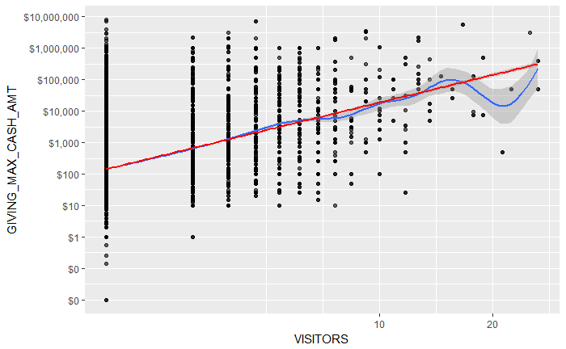

```r
scatterplotter('VISITORS') + scale_x_sqrt()
```

Looks ok.

```r
summary2(full.data$COMMITTEE_NU_DISTINCT %>% sqrt())
```

```
     Min.   1st Qu.    Median      Mean   3rd Qu.      Max.     StDev Skewnewss  Kurtosis
    0.000     0.000     0.000     0.585     1.000     5.920     0.763     1.070     0.689
```

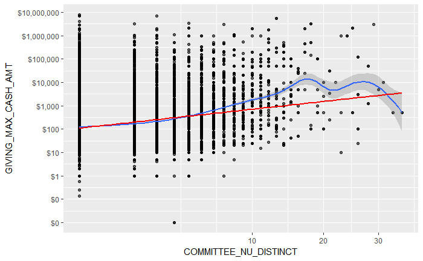

```r
scatterplotter('COMMITTEE_NU_DISTINCT') +
  scale_x_sqrt()
```

Looks like it might be piecewise-linear; consider discretizing. **Consider additional transformation**

```r
summary2(full.data$COMMITTEE_NU_ACTIVE %>% sqrt())
```

```
     Min.   1st Qu.    Median      Mean   3rd Qu.      Max.     StDev Skewnewss  Kurtosis
    0.000     0.000     0.000     0.297     0.000     4.800     0.543     1.610     1.750
```

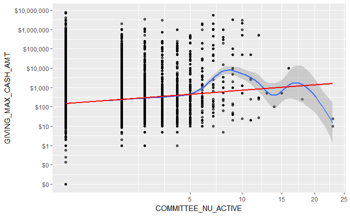

```r
scatterplotter('COMMITTEE_NU_ACTIVE') +
  scale_x_sqrt()
```

Likely unhelpful since I don’t know committees the year largest gift was made. **EXCLUDE**

```r
summary2(full.data$COMMITTEE_NU_YEARS %>% sqrt())
```

```
     Min.   1st Qu.    Median      Mean   3rd Qu.      Max.     StDev Skewnewss  Kurtosis
    0.000     0.000     0.000     0.530     1.000     4.800     0.774     1.260     0.829
```

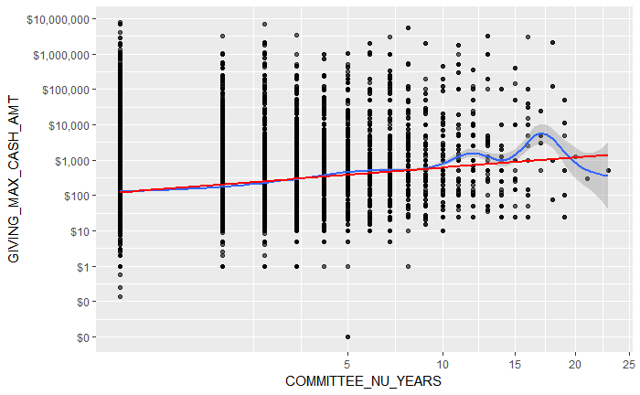

```r
scatterplotter('COMMITTEE_NU_YEARS') +
  scale_x_sqrt()
```

Looks fine.

```r
summary2(full.data$COMMITTEE_KSM_DISTINCT %>% sqrt())
```

```
     Min.   1st Qu.    Median      Mean   3rd Qu.      Max.     StDev Skewnewss  Kurtosis
    0.000     0.000     0.000     0.444     1.000     4.800     0.657     1.160     0.331
```

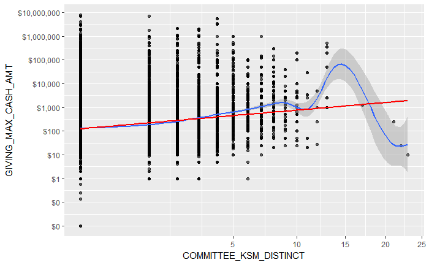

```r
scatterplotter('COMMITTEE_KSM_DISTINCT') +
  scale_x_sqrt()
```

Can probably get away with linear, or discretize. **Consider additional transformation**

```r
summary2(full.data$COMMITTEE_KSM_ACTIVE %>% sqrt())
```

```
     Min.   1st Qu.    Median      Mean   3rd Qu.      Max.     StDev Skewnewss  Kurtosis
    0.000     0.000     0.000     0.225     0.000     4.800     0.462     1.770     1.980
```

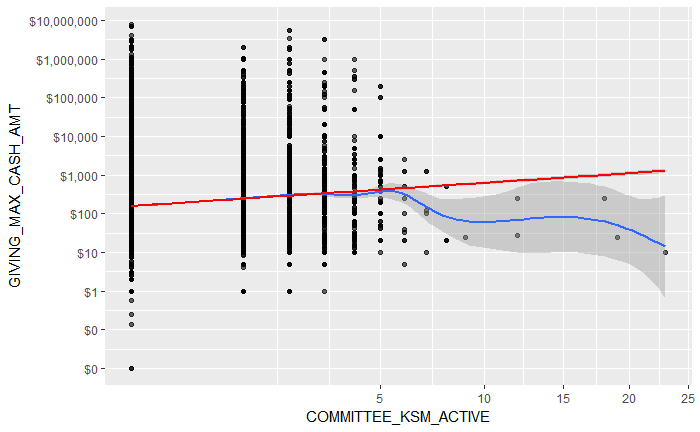

```r
scatterplotter('COMMITTEE_KSM_ACTIVE') +
  scale_x_sqrt()
```

Likely unhelpful since I don’t know committees the year largest gift was made. **EXCLUDE**

```r
summary2(full.data$COMMITTEE_KSM_YEARS %>% sqrt())
```

```
     Min.   1st Qu.    Median      Mean   3rd Qu.      Max.     StDev Skewnewss  Kurtosis
    0.000     0.000     0.000     0.398     1.000     3.610     0.668     1.430     0.959
```

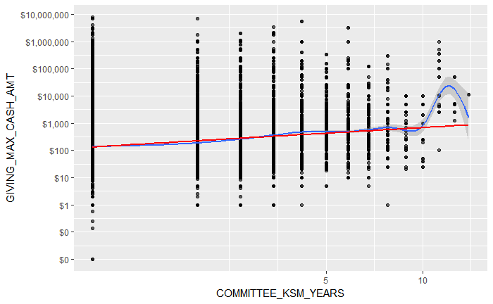

```r
scatterplotter('COMMITTEE_KSM_YEARS') +
  scale_x_sqrt()
```

Looks fine.

```r
summary2(full.data$COMMITTEE_KSM_LDR %>% sqrt())
```

```
     Min.   1st Qu.    Median      Mean   3rd Qu.      Max.     StDev Skewnewss  Kurtosis
   0.0000    0.0000    0.0000    0.0299    0.0000    2.4500    0.1920    6.7000   46.1000
```

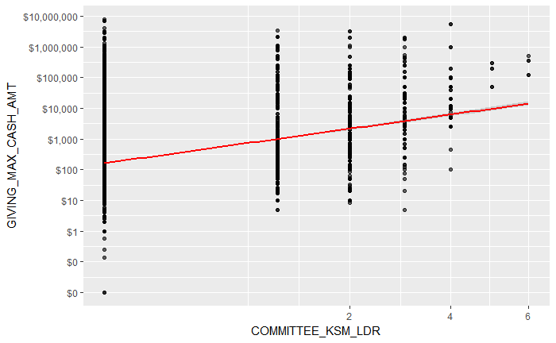

```r
scatterplotter('COMMITTEE_KSM_LDR') +
  scale_x_sqrt()
```

Looks ok but consider combining based on counts. **Consider additional transformation**

```r
summary2(full.data$COMMITTEE_KSM_LDR_ACTIVE %>% sqrt())
```

```
     Min.   1st Qu.    Median      Mean   3rd Qu.      Max.     StDev Skewnewss  Kurtosis
   0.0000    0.0000    0.0000    0.0125    0.0000    2.0000    0.1190    9.7400   96.9000
```